# FS20C3 - Datenjournalismus

Data Analysis

Fernando Millan Villalobos

April 2020

# 1 Notes

This report was generated on 2020-06-05 14:37:08. R version: 4.0.0 on x86_64-w64-mingw32. For this report, CRAN packages as of 2020-06-01 were used.

## 1.1 R-Script & data

The preprocessing and analysis of the data was conducted in the [R project for statistical computing](https://www.r-project.org/). The RMarkdown script used to generate this document and all the resulting data can be downloaded [under this link](http://FernandoMillanVillalobos.github.io/fs20c3_datenjournalismus/). Through executing `main.Rmd`, the herein described process can be reproduced and this document can be generated. In the course of this, data from the folder `input` will be processed and results will be written to `output`. The html on-line version of the analysis can be accessed through this [link](https://FernandoMillanVillalobos.github.io/fs20c3_datenjournalismus/).

## 1.2 GitHub

The code for the herein described process can also be freely downloaded from https://github.com/FernandoMillanVillalobos/fs20c3_datenjournalismus.

## 1.3 Data description of output files

### 1.3.1 `vietnam_bangladesh_wash.csv`

[output not shown]

…

# 2 Set up

```
## [1] "package package:rstudioapi detached"
```

```
## [1] "package package:knitr detached"
```

## 2.1 Define packages

```r
# from https://mran.revolutionanalytics.com/web/packages/\
# checkpoint/vignettes/using-checkpoint-with-knitr.html
# if you don't need a package, remove it from here (commenting not sufficient)
# tidyverse: see https://blog.rstudio.org/2016/09/15/tidyverse-1-0-0/
cat("
library(rstudioapi)
library(tidyverse) # ggplot2, dplyr, tidyr, readr, purrr, tibble, magrittr, readxl
library(lubridate)
library(scales) # scales for ggplot2
library(jsonlite) # json
library(lintr) # code linting
library(sf) # spatial data handling
library(rmarkdown)
library(cowplot) # theme
library(ggridges) # density plots
library(extrafont)", # fonts
file = "manifest.R")
```

## 2.2 Install packages

```r
# if checkpoint is not yet installed, install it (for people using this
# system for the first time)
if (!require(checkpoint)) {
  if (!require(devtools)) {
    install.packages("devtools", repos = "http://cran.us.r-project.org")
    require(devtools)
  }
  devtools::install_github("RevolutionAnalytics/checkpoint",
                           ref = "v0.4.9", # could be adapted later,
                           # as of now (beginning of July 2017
                           # this is the current release on CRAN)
                           repos = "http://cran.us.r-project.org")
  require(checkpoint)
}
# nolint start
if (!dir.exists("~/.checkpoint")) {
  dir.create("~/.checkpoint")
}
# nolint end
# install packages for the specified CRAN snapshot date
checkpoint(snapshotDate = package_date,
           project = path_to_wd,
           verbose = T,
           scanForPackages = T,
           use.knitr = F,
           R.version = r_version)
rm(package_date)
```

## 2.3 Load packages

```r
source("manifest.R")
unlink("manifest.R")
```

## 2.4 Load additional scripts

```r
# if you want to outsource logic to other script files, see README for
# further information
# Load all visualizations functions as separate scripts
knitr::read_chunk("scripts/dviz.supp.R")
source("scripts/dviz.supp.R")
knitr::read_chunk("scripts/themes.R")
source("scripts/themes.R")
knitr::read_chunk("scripts/plot_grid.R")
source("scripts/plot_grid.R")
knitr::read_chunk("scripts/align_legend.R")
source("scripts/align_legend.R")
knitr::read_chunk("scripts/label_log10.R")
source("scripts/label_log10.R")
```

# 3 Introduction

This notebook is thought as a working document for the development and documentation of the [FS20C3 - Datenjournalismus project](https://ds-spaces.technik.fhnw.ch/app/uploads/sites/45/2019/09/hs19c3datenjournalsimus.pdf)).

[AidData](https://www.aiddata.org/) is a research lab at William & Mary’s Global Research Institute. AidData’s interdisciplinary team focus on research and analysis of development investments from more than 90 grants and contracts worth more than $50 million over the last 16 years. Taking as starting point the [data](https://www.aiddata.org/data/aiddata-core-research-release-level-1-3-1) provided by them and after a previous research about media use of the information gathered and made available to the public by this organization, we´ve developed a new data-driven story. In order to do that, data from the core dataset were selected, extracted and analysed to built our written and visual narrative.

The data-driven story we want to tell with the help of the data provided by AidData, is about the successfull and quick development of a national water supply and sanitation net that Vietnam has accomplished in the past two decades. This huge progress has been possible thanks, among other reasons, to a broad international cooperation. In this notebook we´ve dug into the available data to bring into the light the main protagonists of this collaborative achievement and try to picture the time line that makes it a today reality.

With this in mind, we´ve looked for the 3-digit sector classification based on OECD purpose codes that comes in [the documentation of the data](http://docs.aiddata.org/ad4/files/aiddata_coding_scheme_0.pdf) and selected the activities that are related to our main goal.

# 4 Data Importing

The core dataset provided by AidData can be found [here](https://www.aiddata.org/data/aiddata-core-research-release-level-1-3-1). This dataset tracks known international development flows from bilateral and multilateral aid organizations from 1947 to 2013 in a flat-table structure. Information available are served as a granular data from more level of details to a general overview. After getting a first impression of the different datasets that encompass the whole data core and reading the [documentation](https://www.aiddata.org/methods/sdg-coding), we end that the information we need for our story is located in the “thin” version (more than 1.500.000 entries).

```r
# Importing whole dataset
df_full <- read_csv("input/AidDataCoreThin_ResearchRelease_Level1_v3.1.csv")
head(df_full)
```

| aiddata_id | aiddata_2_id | year | donor | recipient | commitment_amount_usd_constant | coalesced_purpose_code | coalesced_purpose_name |
| --- | --- | --- | --- | --- | --- | --- | --- |
| 1 | NA | 2003 | African Development Bank (AFDB) | Togo | 29589911 | 24030 | Formal sector financial intermediaries |
| 2 | NA | 1990 | African Development Bank (AFDB) | Burundi | 9713596 | 31100 | Agriculture, combinations of purposes in Agriculture, Agro-industry, Agribusiness |
| 3 | NA | 1991 | African Development Bank (AFDB) | Cote d`Ivoire | 148139421 | 31120 | Agricultural development |
| 4 | NA | 1992 | African Development Bank (AFDB) | Cameroon | 24693752 | 31120 | Agricultural development |
| 5 | NA | 1992 | African Development Bank (AFDB) | Gabon | 82312507 | 31100 | Agriculture, combinations of purposes in Agriculture, Agro-industry, Agribusiness |
| 6 | NA | 1991 | African Development Bank (AFDB) | Guinea | 67746687 | 31320 | Fishery development |

# 5 Data Pre-Processing

In this step we are going to transform our imported data in a way that allows us to apply further analysis. Typically, this process requires some data wrangling, data transformation and the creation of new variables.

```r
# The 3-digit sector classification based on OECD purpose codes tells us that
# codes beginning with 140 corresponds to “Water Supply and Sanitation”.
# Among the different activities in this category:
# - Water Supply and Sanitation, combination of purposes (14000)
# - Water Supply and Sanitation, purpose unspecified or does not fit under any other applicable codes (14005)
# - Basic drinking water supply and basic sanitation (14030)
# - Waste management/disposal (14050)
# - Education and training in water supply and sanitation (14081)

# Select columns and rows we are interesting in with values different as na´s.
codes <- c(14000, 14005, 14030, 14050, 14081)
years <- 1992:2013
(head(df1 <- df_full %>%
  select(3:8) %>%
  filter((recipient == "Viet Nam" | recipient == "Bangladesh") & (year %in% years) & coalesced_purpose_code %in% codes) %>% # Subjects of our analysis are Viet Nam and Bangladesh
  na.omit()))
```

| year | donor | recipient | commitment_amount_usd_constant | coalesced_purpose_code | coalesced_purpose_name |
| --- | --- | --- | --- | --- | --- |
| 2001 | Asian Development Fund (ASDF) | Bangladesh | 55309088 | 14030 | Basic drinking water supply and basic sanitation |
| 1997 | Asian Development Bank (ASDB) | Viet Nam | 3922870 | 14005 | Water Supply and Sanitation, purpose unspecified or does not fit under any other applicable codes |
| 1993 | Asian Development Bank (ASDB) | Bangladesh | 384259 | 14005 | Water Supply and Sanitation, purpose unspecified or does not fit under any other applicable codes |
| 1996 | OPEC Fund for International Development (OFID) | Viet Nam | 139168 | 14030 | Basic drinking water supply and basic sanitation |
| 1995 | Asian Development Fund (ASDF) | Bangladesh | 42792828 | 14030 | Basic drinking water supply and basic sanitation |
| 1995 | International Fund for Agricultural Development (IFAD) | Bangladesh | 13907669 | 14030 | Basic drinking water supply and basic sanitation |

```r
# Select columns and rows of our operational dataset
(head(df <- df1 %>%
  rename(amount = commitment_amount_usd_constant, code = coalesced_purpose_code, activity = coalesced_purpose_name)))
```

| year | donor | recipient | amount | code | activity |
| --- | --- | --- | --- | --- | --- |
| 2001 | Asian Development Fund (ASDF) | Bangladesh | 55309088 | 14030 | Basic drinking water supply and basic sanitation |
| 1997 | Asian Development Bank (ASDB) | Viet Nam | 3922870 | 14005 | Water Supply and Sanitation, purpose unspecified or does not fit under any other applicable codes |
| 1993 | Asian Development Bank (ASDB) | Bangladesh | 384259 | 14005 | Water Supply and Sanitation, purpose unspecified or does not fit under any other applicable codes |
| 1996 | OPEC Fund for International Development (OFID) | Viet Nam | 139168 | 14030 | Basic drinking water supply and basic sanitation |
| 1995 | Asian Development Fund (ASDF) | Bangladesh | 42792828 | 14030 | Basic drinking water supply and basic sanitation |
| 1995 | International Fund for Agricultural Development (IFAD) | Bangladesh | 13907669 | 14030 | Basic drinking water supply and basic sanitation |

```r
df$donor <- df$donor %>%
  as_factor() %>% # convert variable donor as factor
  recode_factor(
    "United Kingdom" = "UK",
    "Asian Development Bank (ASDB)" = "ASDB",
    "Asian Development Fund (ASDF)" = "ASDF",
    "Asian Development Bank (AsDB Special Funds)" = "AsDB",
    "World Bank - International Development Association (IDA)" = "IDA",
    "United Nations Children`s Fund (UNICEF)" = "UNICEF",
    "OPEC Fund for International Development (OFID)" = "OFID",
    "European Communities (EC)" = "EC",
    "International Fund for Agricultural Development (IFAD)" = "IFAD",
    "Bill & Melinda Gates Foundation" = "B&M",
    "Global Environment Facility (GEF)" = "GEF"
  )

df$recipient <- df$recipient %>%
  as_factor() # convert variable recipient as factor

df$code <- df$code %>%
  as_factor() # convert variable code as factor

df$activity <- df$activity %>%
  as_factor() # convert variable activity as factor

# Export our operational dataset as filtered csv file
# write_csv(df, "output/vietnam_bangladesh_wash.csv")
```

# 6 Exploratory Data Analysis (EDA)

## 6.1 Data Summarization

Now we want to describe some important properties of the distribution of the values across the observations in our datasets, an overview of the key properties of the data.

```r
# How many different donors
(distinct_donors <- unique(df$donor) %>%
  n_distinct())
```

```
## [1] 31
```

```r
# Times and frequency donors contribution
(donors_contrib <- df %>%
  group_by(donor) %>%
  summarize(
    count = n()
  ) %>%
  arrange(desc(count)) %>%
  mutate(freq = count / sum(count),
         pct = round(freq * 100, 1)) %>%
  select(donor, count, pct))
```

| donor | count | pct |
| --- | --- | --- |
| UNICEF | 126 | 22.6 |
| Germany | 68 | 12.2 |
| Japan | 39 | 7.0 |
| Australia | 39 | 7.0 |
| Denmark | 28 | 5.0 |
| France | 27 | 4.8 |
| Finland | 26 | 4.7 |
| Belgium | 25 | 4.5 |
| Netherlands | 21 | 3.8 |
| Norway | 20 | 3.6 |
| Switzerland | 20 | 3.6 |
| Korea | 17 | 3.0 |
| UK | 16 | 2.9 |
| ASDB | 13 | 2.3 |
| Italy | 13 | 2.3 |
| Sweden | 12 | 2.2 |
| Spain | 7 | 1.3 |
| AsDB | 5 | 0.9 |
| IDA | 5 | 0.9 |
| B&M | 5 | 0.9 |
| Canada | 4 | 0.7 |
| United States | 4 | 0.7 |
| Luxembourg | 4 | 0.7 |
| ASDF | 3 | 0.5 |
| EC | 3 | 0.5 |
| GEF | 2 | 0.4 |
| Czech Republic | 2 | 0.4 |
| OFID | 1 | 0.2 |
| IFAD | 1 | 0.2 |
| United Arab Emirates | 1 | 0.2 |
| New Zealand | 1 | 0.2 |

From our primary data exploration we can see that there´re a total of **31**. Donors that have contributed more frequently are UNICEF (**22.6%**) , Germany (**12.2%**) and Japan (**7%**). These three main donors represent together up to **41.8%** from all contributions. On the other hand, donors like New Zealand (**0.2%**), United Arab Emirates (**0.2%**) and IFAD (**0.2%**) are located at the bottom of the distribution with an all together total percentage of less than **1%**.

```r
# Finding the most common values of our quantitative variable in our sample.
select(df, amount) %>%
  summarise_each(list(max = max, min = min, mean = mean, median = median, var = var, sd = sd, IQR = IQR))
```

| max | min | mean | median | var | sd | IQR |
| --- | --- | --- | --- | --- | --- | --- |
| 341355248 | 19 | 5432362 | 122456.5 | 676880696182605 | 26016931 | 950428.2 |

```r
# Donors amount ranking distribution
(donors_ranking_amount <- df %>%
  group_by(donor) %>%
  summarize(
    total_amount = sum(amount),
    mean = mean(amount),
    median = median(amount),
    max = max(amount),
    min = min(amount)
  ) %>%
  arrange(desc(total_amount)) %>%
  mutate(freq = total_amount / sum(total_amount),
         pct = round(freq * 100, 4)) %>%
  select(donor, total_amount, pct, mean, median, max, min))
```

| donor | total_amount | pct | mean | median | max | min |
| --- | --- | --- | --- | --- | --- | --- |
| Japan | 909821461 | 30.0146 | 23328755.41 | 87184.0 | 341355248 | 113 |
| IDA | 469743273 | 15.4966 | 93948654.60 | 95877868.0 | 204415458 | 1533116 |
| ASDB | 393935850 | 12.9958 | 30302757.69 | 835006.0 | 208415258 | 494 |
| Denmark | 251442355 | 8.2950 | 8980084.11 | 2420195.0 | 62723129 | 60952 |
| UK | 193134424 | 6.3714 | 12070901.50 | 2703994.5 | 63577280 | 104606 |
| ASDF | 188360400 | 6.2139 | 62786800.00 | 55309088.0 | 90258484 | 42792828 |
| Germany | 112467377 | 3.7103 | 1653932.01 | 123068.5 | 60363828 | 1051 |
| Australia | 108437055 | 3.5773 | 2780437.31 | 292682.0 | 21981183 | 2649 |
| Finland | 83185295 | 2.7442 | 3199434.42 | 205871.5 | 21756606 | 2735 |
| Switzerland | 65767420 | 2.1696 | 3288371.00 | 1978061.5 | 15486200 | 50542 |
| Netherlands | 50803351 | 1.6760 | 2419207.19 | 191700.0 | 18259485 | 1589 |
| Korea | 31486997 | 1.0387 | 1852176.29 | 53695.0 | 25599209 | 6966 |
| AsDB | 29207628 | 0.9635 | 5841525.60 | 6390090.0 | 14264648 | 491545 |
| Belgium | 22764482 | 0.7510 | 910579.28 | 197829.0 | 10986005 | 413 |
| France | 20517428 | 0.6769 | 759904.74 | 74159.0 | 13889113 | 2114 |
| Italy | 20375455 | 0.6722 | 1567342.69 | 32059.0 | 19222480 | 204 |
| Sweden | 15320577 | 0.5054 | 1276714.75 | 202835.5 | 6318190 | 24250 |
| UNICEF | 14990198 | 0.4945 | 118969.83 | 15667.5 | 3184189 | 19 |
| IFAD | 13907669 | 0.4588 | 13907669.00 | 13907669.0 | 13907669 | 13907669 |
| Spain | 12788206 | 0.4219 | 1826886.57 | 103808.0 | 8184953 | 62956 |
| Norway | 11169762 | 0.3685 | 558488.10 | 94787.0 | 2974614 | 4115 |
| B&M | 4011180 | 0.1323 | 802236.00 | 722613.0 | 1497203 | 41137 |
| GEF | 2993512 | 0.0988 | 1496756.00 | 1496756.0 | 2949273 | 44239 |
| EC | 2079758 | 0.0686 | 693252.67 | 567959.0 | 1351679 | 160120 |
| Luxembourg | 993774 | 0.0328 | 248443.50 | 94495.0 | 796252 | 8532 |
| New Zealand | 552748 | 0.0182 | 552748.00 | 552748.0 | 552748 | 552748 |
| Czech Republic | 428619 | 0.0141 | 214309.50 | 214309.5 | 343740 | 84879 |
| United States | 406231 | 0.0134 | 101557.75 | 101470.0 | 177053 | 26238 |
| OFID | 139168 | 0.0046 | 139168.00 | 139168.0 | 139168 | 139168 |
| Canada | 16863 | 0.0006 | 4215.75 | 5174.5 | 6113 | 401 |
| United Arab Emirates | 9518 | 0.0003 | 9518.00 | 9518.0 | 9518 | 9518 |

```r
# Total amount given for all donors to Vietnam and Bangladesh from 1992 to 2013
(total_amount_donors <- sum(donors_ranking_amount$total_amount))
```

```
## [1] 3031258034
```

The total amount both countries has received from the 31 donors during the period that goes from 1992 to 2013 (dataset) was **3031258034 USD**.

## 6.2 Data Visualization

We´re going to explore and gain insights from our data using one of the most outstanding ability of human beings: capturing visual patterns. Let´s explore distributions of key variables (donor, amount and activity), associations among them and time development in our dataset.

### 6.2.1 Donors Distribution

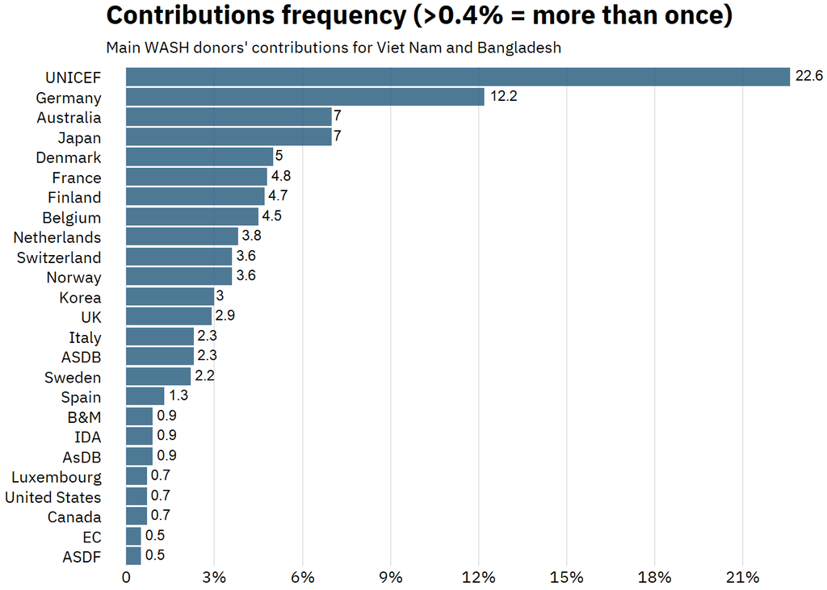

```r
# Bar plot
p1 <-ggplot(subset(donors_contrib, donors_contrib$pct > .4), aes(x = fct_reorder(donor, pct), y = pct)) +
  geom_col(fill = "#22577a", alpha = .8) +
  scale_y_continuous(
    expand = c(0, 0.7),
    breaks = seq(0, 21, 3),
    labels = c("0", "3%", "6%", "9%", "12%", "15%", "18%", "21%"),
    name = NULL) +
  scale_x_discrete(name = NULL,
                   expand = c(0, 0.5)) +
  geom_text(aes(label = pct), hjust = -.2, vjust = .3, colour = "black", size = 3) +
  labs(title = "Contributions frequency (>0.4% = more than once)",
       subtitle = "Main WASH donors' contributions for Viet Nam and Bangladesh") +
  coord_flip(clip = "off") +
  theme_dviz_vgrid(rel_small = .7) +
  theme(
    axis.ticks.length = grid::unit(0, "pt"),
    axis.line.y = element_blank(),
    axis.ticks.y = element_blank(),
    plot.margin = margin(3, 10, 3, 3)) #top, right, bottom and left
p1
```

```r
# Distribution donors total contributions per recipient
donors_contrib_per_recipient <- df %>%
  group_by(recipient) %>%
  summarize(
    count = n()
    ) %>%
  mutate(freq = count / sum(count),
         pct = round(freq * 100, 1)) %>%
  arrange(desc(pct)) %>%
  select(recipient, count, pct)
```

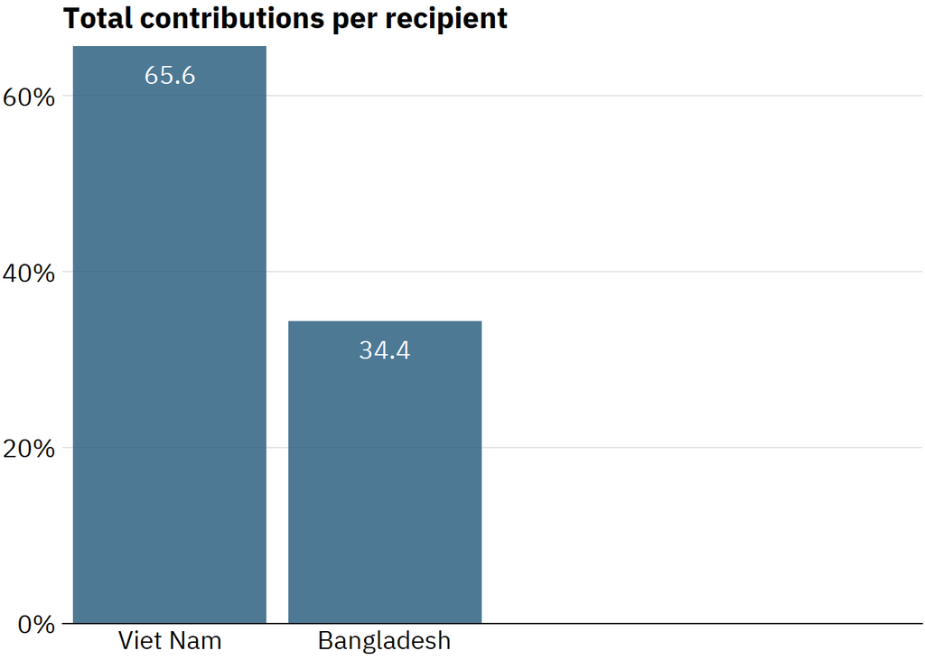

```r
# Bar plot
p2 <- ggplot(donors_contrib_per_recipient, aes(x = fct_reorder(recipient, desc(pct)), y = pct)) +
  geom_col(fill = "#22577a", alpha = .8) +
  geom_text(aes(label = pct), vjust = 2, color = "white", size = 14/.pt, family = dviz_font_family) +
  scale_y_continuous(
    expand = c(0, 0),
    labels = c("0%", "20%", "40%", "60%"),
    name = NULL) +
  scale_x_discrete(name = NULL,
                   expand = c(0, .5, .5, 2)) +
  labs(title = "Total contributions per recipient") +
  theme_dviz_hgrid(rel_small = 1) +
  theme(
    axis.line.x.bottom = element_line(size = .5, color = "black"),
    axis.ticks.length = grid::unit(0, "pt"),
    axis.line.y = element_blank(),
    axis.ticks.y = element_blank())
p2
```

```r
# Distribution donors total contributions per donor and recipient
donors_contrib_per_donor_recipient <- df %>%
  group_by(donor, recipient) %>%
  summarize(
    count = n()
  ) %>%
  arrange(desc(count)) %>%
  mutate(freq = count / sum(count),
         pct = round(freq * 100, 1)) %>%
  select(donor, recipient, count)
```

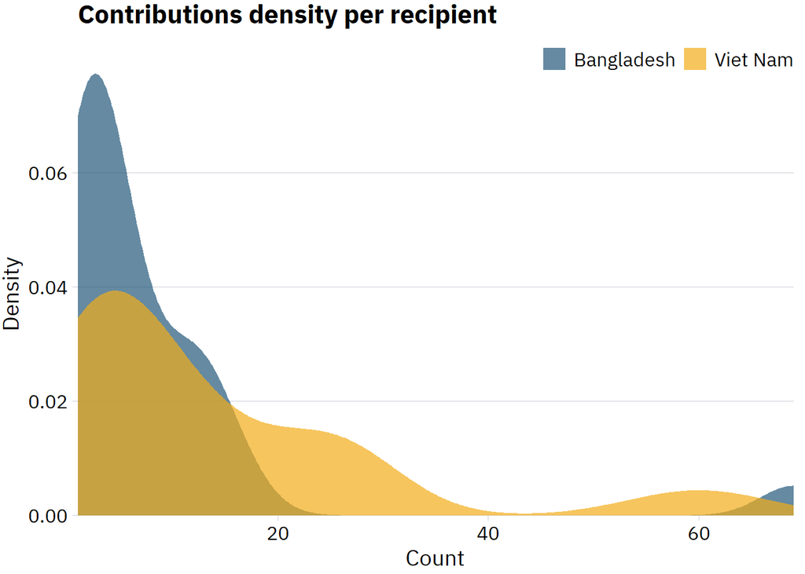

```r
# Density plot one distribution
p3 <- ggplot(donors_contrib_per_donor_recipient, aes(x = count, fill = recipient)) +
  geom_density_line(alpha = .7, kernel = "gaussian", color = "transparent") +
  scale_y_continuous(name = "Density", expand = c(0, 0)) +
  scale_x_continuous(name = "Count", expand = c(0, 0)) +
  scale_fill_manual(
    values = c("#22577a", "#f2ac18"),
    name = NULL,
    guide = guide_legend(direction = "horizontal")) +
  labs(title = "Contributions density per recipient") +
  theme_dviz_hgrid() +
  theme(
    axis.line.x = element_blank(),
    plot.margin = margin(3, 7, 3, 1.5),
    strip.text = element_text(size = 14, margin = margin(0, 0, 0.2, 0, "cm")),
    legend.position = "top",
    legend.justification = "right",
    legend.margin = margin(4.5, 0, 1.5, 0, "pt"),
    legend.spacing.x = grid::unit(4.5, "pt"),
    legend.spacing.y = grid::unit(0, "pt"),
    legend.box.spacing = grid::unit(0, "cm"))
p3
```

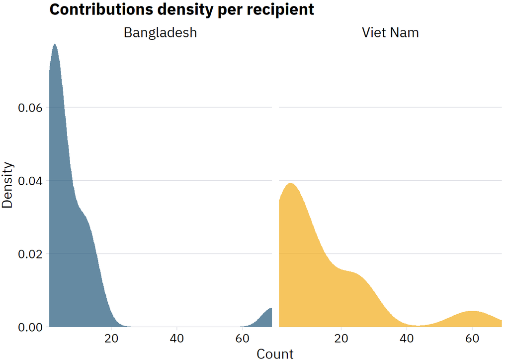

```r
# Density plot multiple distributions
p4 <- ggplot(donors_contrib_per_donor_recipient, aes(x = count, fill = recipient)) +
  geom_density_line(alpha = .7, kernel = "gaussian", color = "transparent") +
  scale_y_continuous(name = "Density", expand = c(0, 0)) +
  scale_x_continuous(name = "Count", expand = c(0, 0)) +
  scale_fill_manual(
    values = c("#22577a", "#f2ac18"),
    name = NULL,
    guide = NULL) +
  labs(title = "Contributions density per recipient") +
  facet_wrap(~recipient) +
  theme_dviz_hgrid() +
  theme(
    axis.line.x = element_blank(),
    plot.margin = margin(3, 7, 3, 1.5),
    strip.text = element_text(size = 14, margin = margin(0, 0, 0.2, 0, "cm")))
p4
```

```r
# Distribution donors total contributions per donor
donors_contrib_per_donor_recipient_ungroup_recipient <- df %>%
  group_by(donor) %>%
  summarize(
    count = n()
  ) %>%
  arrange(desc(count)) %>%
  mutate(freq = count / sum(count),
         pct = round(freq * 100, 1)) %>%
  select(donor, count)
```

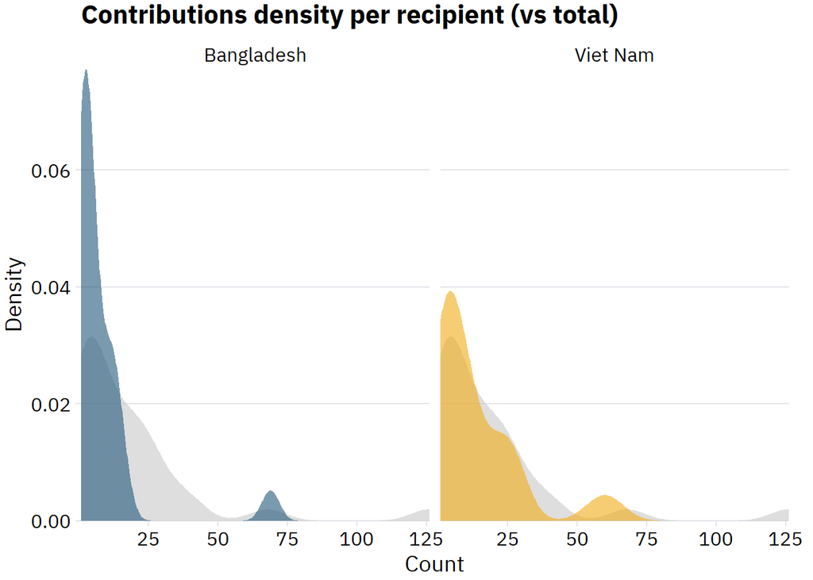

```r
# Density plot multiple distributions against background
p5 <- ggplot(donors_contrib_per_donor_recipient, aes(x = count, fill = recipient)) +
  geom_density_line(data = donors_contrib_per_donor_recipient_ungroup_recipient, alpha = .5, kernel = "gaussian", fill = "grey", color = "transparent") +
  geom_density_line(data = donors_contrib_per_donor_recipient, alpha = .6, color = "transparent") +
  scale_y_continuous(name = "Density", expand = c(0, 0)) +
  scale_x_continuous(name = "Count", expand = c(0, 0)) +
  scale_fill_manual(
    values = c("#22577a", "#f2ac18"),
    name = NULL,
    guide = NULL) +
  labs(title = "Contributions density per recipient (vs total)") +
  theme_dviz_hgrid() +
  facet_wrap(~recipient) +
  theme(
    axis.line.x = element_blank(),
    plot.margin = margin(3, 15, 3, 3))
p5
```

```r
# Distributions donor´s contribution per year and recipient
donors_contrib_timeline_recipient <- df %>%
  group_by(year, recipient) %>%
  summarize(
    count = n()
  ) %>%
  arrange(year) %>%
  select(year, count, recipient)
```

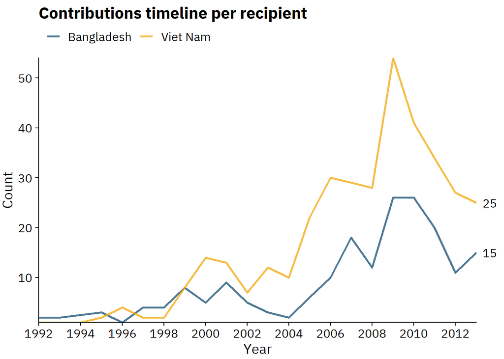

```r
# Transform variable year as date
donors_contrib_timeline_recipient$year <- donors_contrib_timeline_recipient$year %>%
  make_date()

# Get a vector of the last values
donors_contrib_timeline_recipient_ends <- donors_contrib_timeline_recipient %>%
  group_by(recipient) %>%
  top_n(1, year) %>%
  pull(count)

# Timeline
p6 <- ggplot(donors_contrib_timeline_recipient, aes(x = year, y = count, color = recipient)) +
  geom_line(size = 1, alpha = .8) +
  scale_y_continuous(
    expand = c(0, 0),
    name = "Count",
    sec.axis = sec_axis(~ ., breaks = donors_contrib_timeline_recipient_ends)) +
  scale_x_date(
    expand = c(0, 0),
    name = "Year",
    date_breaks = "2 years",
    date_labels = "%Y") +
  scale_color_manual(
    values = c("#22577a", "#f2ac18"),
    name = NULL) +
  labs(
    title = "Contributions timeline per recipient") +
  theme_dviz_open() +
  theme(
    axis.line.y.right = element_blank(),
    axis.ticks.y.right = element_blank(),
    plot.margin = margin(7, 7, 3, 2),
    legend.position = "top")
p6
```

### 6.2.2 Amount Distribution

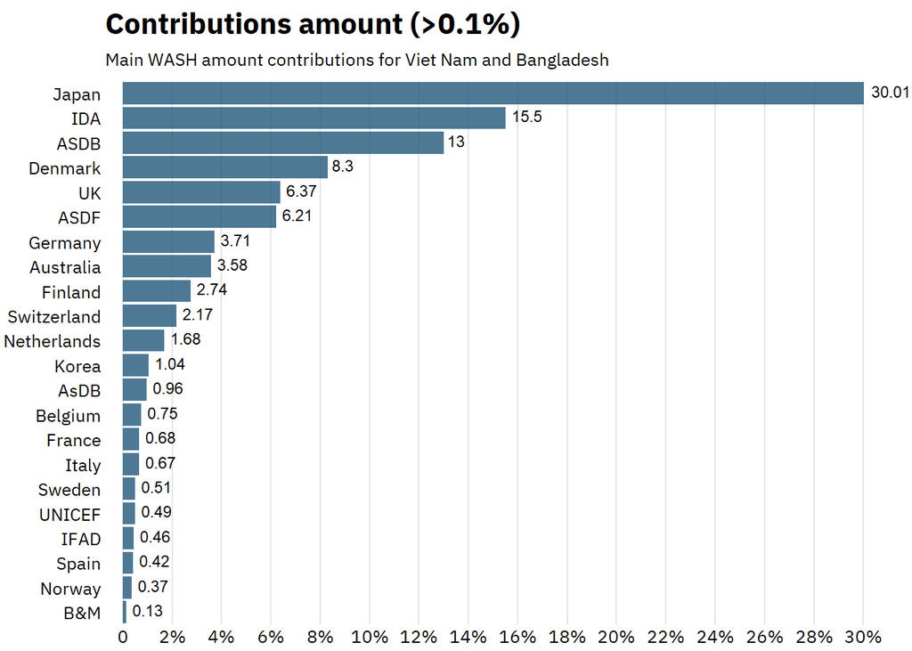

```r
# Distribution donors total amount
# Bar plot
p7 <- ggplot(subset(donors_ranking_amount, donors_ranking_amount$pct > 0.1), aes(x = fct_reorder(donor, pct), y = pct)) +
  geom_col(fill = "#22577a", alpha = .8) +
  scale_y_continuous(
    expand = c(0, 0.7),
    breaks = seq(0, 30, 2),
    labels = c("0", "2%", "4%", "6%", "8%", "10%", "12%", "14%", "16%", "18%", "20%", "22%", "24%", "26%", "28%", "30%"),
    name = NULL) +
  geom_text(aes(label = round(pct, 2)), hjust = -.2, vjust = .3, colour = "black", size = 3) +
  scale_x_discrete(name = NULL,
                   expand = c(0, 0.5)) +
  labs(title = "Contributions amount (>0.1%)",
       subtitle = "Main WASH amount contributions for Viet Nam and Bangladesh") +
  coord_flip(clip = "off") +
  theme_dviz_vgrid(rel_small = .7) +
  theme(
    axis.ticks.length = grid::unit(0, "pt"),
    axis.line.y = element_blank(),
    axis.ticks.y = element_blank(),
    plot.margin = margin(c(7, 17, 3, 2)))
p7
```

```r
# Distribution of amount per donor and recipient
donors_ranking_amount_per_recipient <- df %>%
  group_by(donor, recipient) %>%
  summarize(
    total_amount = sum(amount)
  ) %>%
  mutate(freq = total_amount / sum(total_amount),
         pct = round(freq * 100, 2)) %>%
  ungroup() %>%
  arrange(recipient, pct) %>%
  mutate(order = row_number()) %>%
  select(donor, pct, recipient, order)
```

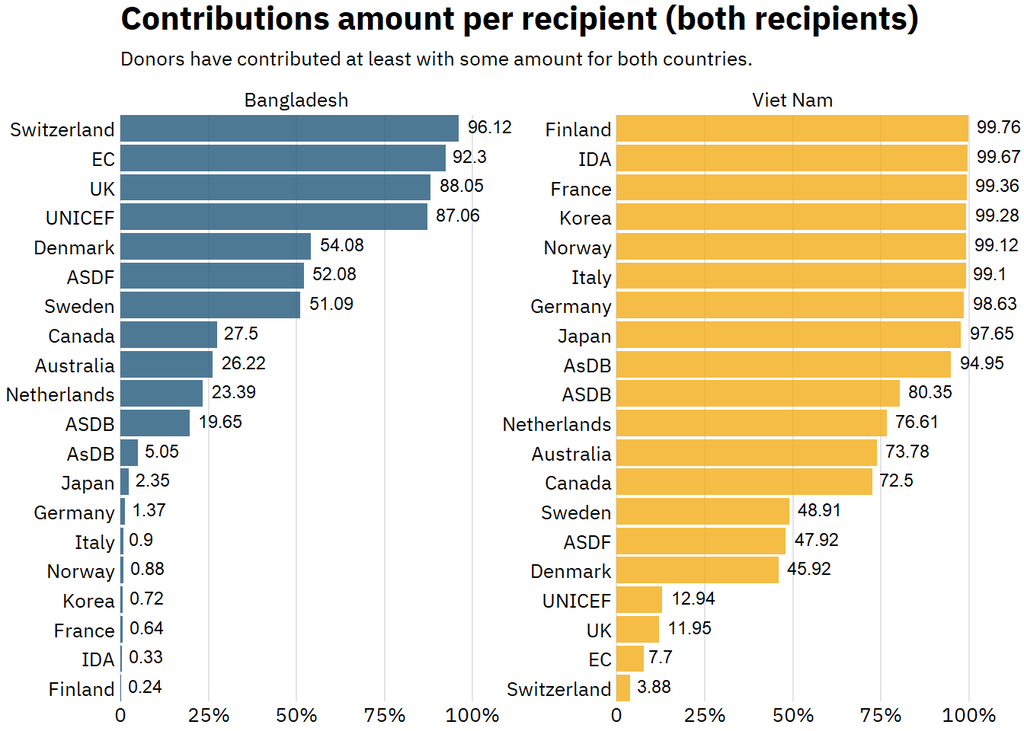

```r
# Bar plot
p8 <- ggplot(subset(donors_ranking_amount_per_recipient, donors_ranking_amount_per_recipient$pct != 100), aes(x = order, y = pct, fill = recipient)) +
  geom_col(position = "dodge", alpha = .8) +
  facet_wrap(~recipient, scales = "free") +
  scale_y_continuous(
    expand = c(0, 0),
    limits = c(0, 100),
    breaks = c(0, 25, 50, 75, 100),
    labels = c("0", "25%", "50%", "75%", "100%"),
    name = NULL) +
  scale_x_continuous(name = NULL,
                   expand = c(0, 0),
                   breaks = donors_ranking_amount_per_recipient$order,
                   labels = donors_ranking_amount_per_recipient$donor) +
  scale_fill_manual(values = c("#22577a", "#f2ac18"),
    name = NULL) +
  geom_text(aes(label = round(pct, 2)), hjust = -.2, vjust = .3, colour = "black", size = 3) +
  labs(title = "Contributions amount per recipient (both recipients)",
       subtitle = "Donors have contributed at least with some amount for both countries.") +
  coord_flip(clip = "off") +
  theme_dviz_vgrid(rel_small = .7) +
  theme(
    axis.ticks.length = grid::unit(0, "pt"),
    axis.line.y = element_blank(),
    axis.ticks.y = element_blank(),
    legend.position = "none",
    panel.spacing.x = unit(1, "lines"),
    plot.margin = margin(3, 27, 3, 3))
p8
```

```r
# Donors amount ranking distribution per year
donors_ranking_amount_timeline <- df %>%
  group_by(year, recipient) %>%
  summarize(
    total_amount = sum(amount),
    mean = mean(amount),
    median = median(amount),
    max = max(amount),
    min = min(amount)
  ) %>%
  arrange(year) %>%
  mutate(freq = total_amount / sum(total_amount),
         pct = round(freq * 100, 4)) %>%
  select(year, total_amount, recipient)
```

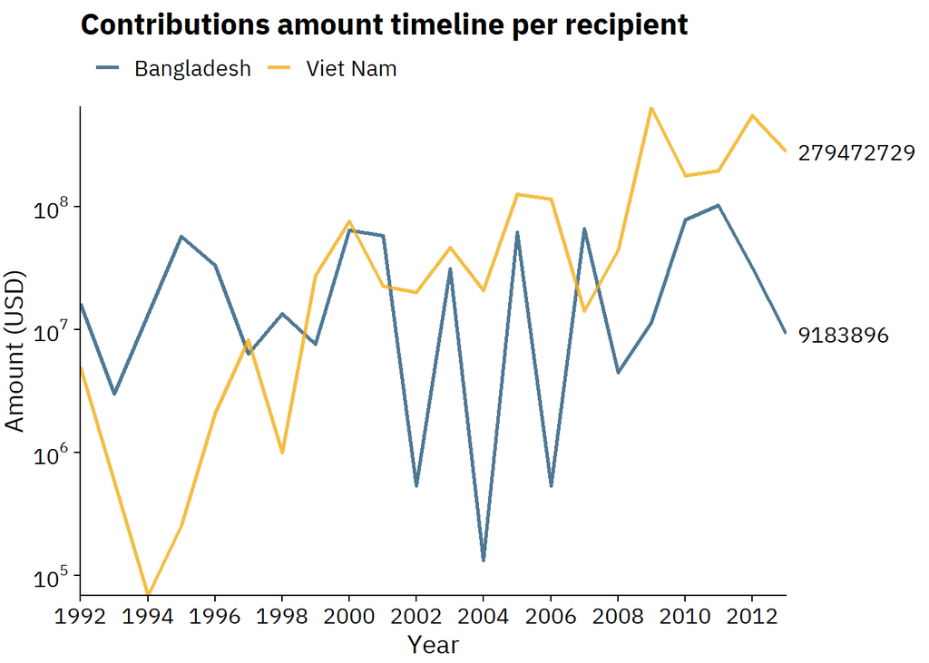

```r
# Transform variable year as date
donors_ranking_amount_timeline$year <- donors_ranking_amount_timeline$year %>%
  make_date()

# Get a vector of the last values
donors_ranking_amount_timeline_ends <- donors_ranking_amount_timeline %>%
  group_by(recipient) %>%
  top_n(1, year) %>%
  pull(total_amount)

# Timeline
p9 <- ggplot(donors_ranking_amount_timeline, aes(x = year, y = total_amount, color = recipient)) +
  geom_line(size = 1, alpha = .8) +
  scale_y_log10(
    breaks = trans_breaks("log10", function(x) 10^x),
    labels = trans_format("log10", math_format(10^.x)),
    expand = c(0, 0),
    name = "Amount (USD)",
    sec.axis = sec_axis(~ ., breaks = donors_ranking_amount_timeline_ends)) +
  scale_x_date(
    expand = c(0, 0),
    name = "Year",
    date_breaks = "2 years",
    date_labels = "%Y") +
  scale_color_manual(
    values = c("#22577a", "#f2ac18"),
    name = NULL) +
  labs(
    title = "Contributions amount timeline per recipient") +
  theme_dviz_open() +
  theme(
    axis.line.y.right = element_blank(),
    axis.ticks.y.right = element_blank(),
    plot.margin = margin(7, 7, 3, 2),
    legend.position = "top")
p9
```

```r
# Donors amount ranking distribution per year
donors_ranking_amount_timeline_summary <- df %>%
  group_by(year, recipient) %>%
  summarize(
    total_amount = sum(amount),
    mean = mean(amount),
    median = median(amount),
    max = max(amount),
    min = min(amount)
  ) %>%
  arrange(year) %>%
  mutate(freq = total_amount / sum(total_amount),
         pct = round(freq * 100, 4)) %>%
  select(year, total_amount, mean, median, recipient)
```

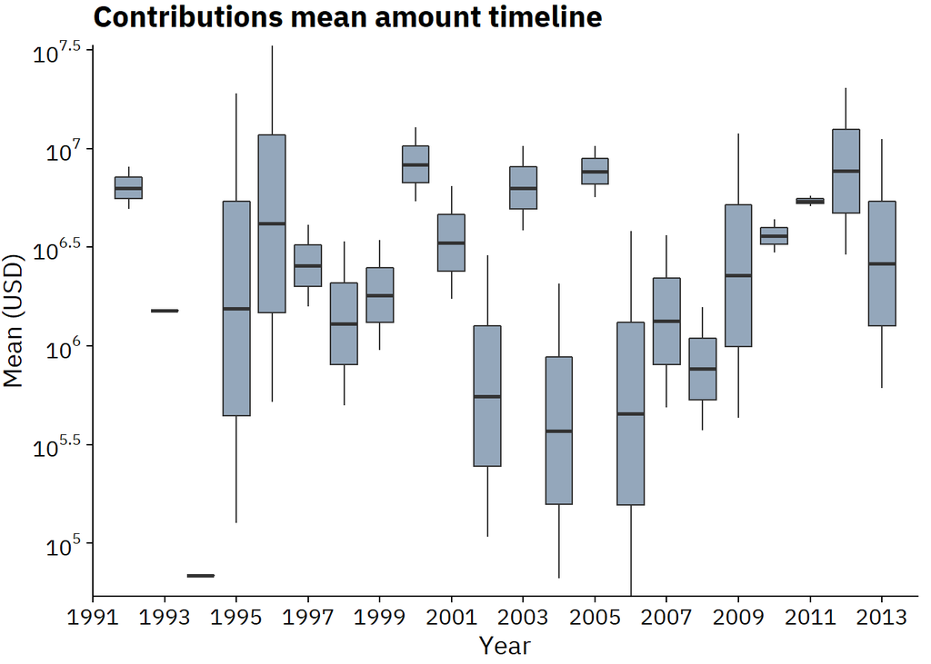

```r
# Transform variable year as date
donors_ranking_amount_timeline_summary$year <- donors_ranking_amount_timeline_summary$year %>%
  make_date()

# Box plot
p10 <- ggplot(donors_ranking_amount_timeline_summary, aes(x = year, y = mean, group = year)) +
  geom_boxplot(fill = "#94a7bb", na.rm = TRUE) +
  scale_y_log10(
  breaks = trans_breaks("log10", function(x) 10^x),
  labels = trans_format("log10", math_format(10^.x)),
  expand = c(0, 0),
  name = "Mean (USD)") +
  scale_x_date(
  expand = c(0, 0),
  limits = as.Date(c("1991-01-01", "2014-01-01")),
  name = "Year",
  date_breaks = "2 years",
  date_labels = "%Y") +
  theme_dviz_open() +
    labs(
  title = "Contributions mean amount timeline") +
  theme(plot.margin = margin(3, 7, 3, 1.5))
p10
```

### 6.2.3 Activities Distribution

```r
# Times and frequency activities
(activities_distrib <- df %>%
  group_by(code, recipient) %>%
  summarize(
    count = n()
  ) %>%
  arrange(desc(code)) %>%
  mutate(freq = count / sum(count),
         pct = round(freq * 100, 1)) %>%
  select(code, recipient, pct))
```

| code | recipient | pct |
| --- | --- | --- |
| 14081 | Bangladesh | 32.6 |
| 14081 | Viet Nam | 67.4 |
| 14050 | Bangladesh | 21.1 |
| 14050 | Viet Nam | 78.9 |
| 14030 | Bangladesh | 39.3 |
| 14030 | Viet Nam | 60.7 |
| 14005 | Bangladesh | 29.6 |
| 14005 | Viet Nam | 70.4 |
| 14000 | Bangladesh | 30.0 |
| 14000 | Viet Nam | 70.0 |

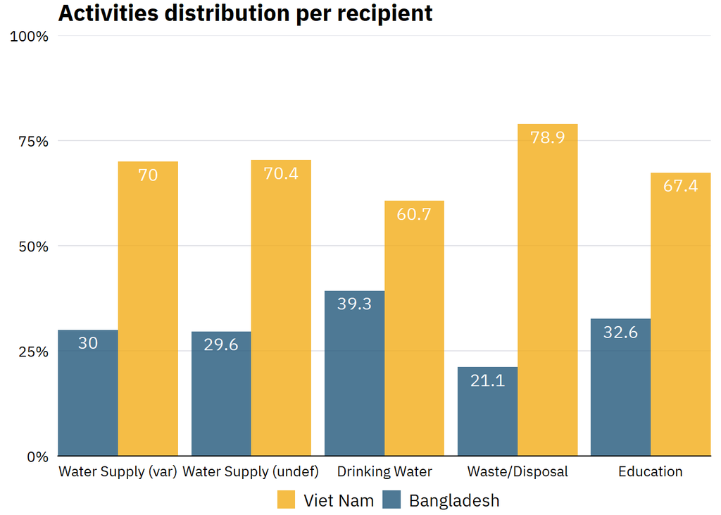

```r
# Rename code activities for presentation
activities_distrib$code <- activities_distrib$code %>%
  recode_factor(
    "14000" = "Water Supply (var)",
    "14005" = "Water Supply (undef)",
    "14030" = "Drinking Water",
    "14050" = "Waste/Disposal",
    "14081" = "Education"
  )

# Grouped bar plot
p11 <- ggplot(activities_distrib, aes(x = code, y = pct, fill = recipient, labels = pct)) +
  geom_bar(position = "dodge", stat = "identity", size = 1, width = .9, alpha = .8) +
  geom_text(aes(label = pct), vjust = 1.5, color = "white", size = 12/.pt, family = dviz_font_family, position = position_dodge2(.9)) +
  scale_x_discrete(expand = c(0, 0), name = NULL) +
  scale_y_continuous(labels = scales::percent_format(accuracy = TRUE, scale = 1), name = NULL, expand = c(0, 0), limits = c(0, 100)) +
  scale_fill_manual(
    values = c("#f2ac18", "#22577a"),
    breaks = c("Viet Nam", "Bangladesh"),
    labels = c("Viet Nam", "Bangladesh"),
    name = NULL
  ) +
  theme_dviz_hgrid() +
  theme(
    axis.line.x.bottom = element_line(size = .5, color = "black"),
    plot.margin = margin(3, 7, 3, 7),
    axis.ticks = element_blank(),
    axis.text = element_text(size = 10),
    legend.position = "bottom",
    legend.justification = "center",
    legend.background = element_rect(fill = "white"),
    legend.spacing.x = grid::unit(4.5, "pt"),
    legend.spacing.y = grid::unit(0, "cm"),
    legend.box.spacing = grid::unit(7, "pt")
    ) +
  labs(title = "Activities distribution per recipient")
p11
```

## 6.3 Linting

The code in this RMarkdown is linted with the [lintr package](https://github.com/jimhester/lintr), which is based on the [tidyverse style guide](http://style.tidyverse.org/).

```r
lintr::lint("main.Rmd", linters =
              lintr::with_defaults(
                commented_code_linter = NULL,
                trailing_whitespace_linter = NULL
                )
            )
```